# BigData with R project: Airbnb data analysis

2024-03-26

[figure not shown]

# Introduction

This file contains all R codes used for general analysis of the Airbnb dataset for the “BigData programming with R” project at DSTI.

More advanced analysis are featured on the Shiny apps, that have been regrouped in a flex dashboard (flex.Rmd).

This project has been prepared by Ken Chevallier, student of A23 cohort in Applied MSc in Data Analytics curriculum.

# 1. Prepare environment and load the data

```r
rm(list=ls())
setwd("C:/DSTI_Courses/Big Data Processing with R/Project")
load("AirBnB (1).Rdata")
```

```r
library(ggplot2)
library(dplyr)
library(shiny)
library(leaflet)
library(stringr)
library(tidyr)
```

# 2. Inspect data structure

```r
summary(R)
```

```
##    listing_id               date
##  Min.   :    2623   2015-09-21:  2759
##  1st Qu.:  946745   2016-05-08:  2660
##  Median : 2742013   2016-05-29:  2278
##  Mean   : 3704145   2016-06-12:  2278
##  3rd Qu.: 5775457   2016-01-05:  2246
##  Max.   :13806306   2016-06-13:  2245
##                     (Other)   :649133
```

> R is a dataframe containing the record of the dates of visits for every rental place.

```r
colnames(L)
```

```
##  [1] "id"                               "listing_url"
##  [3] "scrape_id"                        "last_scraped"
##  [5] "name"                             "summary"
##  [7] "space"                            "description"
##  [9] "experiences_offered"              "neighborhood_overview"
## [11] "notes"                            "transit"
## [13] "access"                           "interaction"
## [15] "house_rules"                      "thumbnail_url"
## [17] "medium_url"                       "picture_url"
## [19] "xl_picture_url"                   "host_id"
## [21] "host_url"                         "host_name"
## [23] "host_since"                       "host_location"
## [25] "host_about"                       "host_response_time"
## [27] "host_response_rate"               "host_acceptance_rate"
## [29] "host_is_superhost"                "host_thumbnail_url"
```

[output cut: 33 more lines]

> L is the dataframe containing the description features of all the rental places, including price, zipcode, neighborhood, address, and so on.  
> Let’s already check data types of two of the most valuable columns, **price and date**, and convert them.

```r
# Check data types of price and date, and already convert them for appropriate use
class(L$price)
```

```
## [1] "factor"
```

```r
class(R$date)
```

```
## [1] "factor"
```

```r
# Convert price column to numeric
L$price <- as.numeric(gsub("[$,]", "", L$price))
# Convert the date column to Date
R$date <- as.Date(R$date)
```

## Overview of the data

### We use table and summary functions to explore each column in the dataset.

```r
table(L$zipcode)
```

```
##
##                                  13006        17200       700014         7009
##          504            1            1            1            1            1
##        74000           75       75 018        75000        75001       750016
##            1            5            1            1         1101            1
##        75002        75003        75004        75005        75006        75007
##         1565         1942         1800         1990         1825         1525
##        75008        75009        75010       750109        75011  75011 PARIS
##         1411         2318         3511            1         4825            1
##        75012        75013        75014 75014\n75014        75015        75016
##         2082         1858         2093            1         3799         1566
##        75017        75018        75019 75019\n75019        75020        75106
##         3465         5973         2652            1         2859            1
##        75116         7517        75522        78008        79019        91330
##         1336            1            1            1            1            1
##        92100        92110        92120        92130        92150        92170
##           66           37           23           52            7           14
##        92200        92210        92240        92300        92800        93100
##           75            7            8           52            1            4
##        93170        93210        93260        93300        93310        93320
##           25            1           14           17           25            1
##        93400        93500        94120        94130        94160        94200
##           27           24            8            5           24           21
##        94220        94230        94250        94270        94300        94340
##           23            1           25           29           60            2
##        94410        95000        95170          adf   Montmartre        Paris
##           13            1            4            1            1            2
##  Paris 75004
##            1
```

> There are several typos on zipcode. Most of them have no impact on the analysis (*price < $200*), except maybe for 2 (priced at $852 and $596, zipcodes 75 and adf), so we’ll fix just theses ones (based on street info).  
> Also, one must know that actually, **16th district has 2 zipcodes: 75016 and 75116 !!!** So we’ll change the 75116 values to reflect this.

```r
as.character(L$street[L$id == 3430844])
```

```
## [1] "Rue Jules César, Paris, Île-de-France 75, France"
```

```r
as.character(L$street[L$id == 6091749])
```

```
## [1] "Rue Saint-Martin, Paris, Île-de-France adf, France"
```

```r
L$zipcode[L$id == 3430844] = 75012
L$zipcode[L$id == 6091749] = 75003
L$zipcode[L$zipcode == 75116] = 75016
```

# 3. Handling missing values

```r
colSums(is.na(L))
```

```
##                               id                      listing_url
##                                0                                0
##                        scrape_id                     last_scraped
##                                0                                0
##                             name                          summary
##                                0                                0
##                            space                      description
##                                1                                0
##              experiences_offered            neighborhood_overview
##                                0                                1
##                            notes                          transit
##                                3                                1
##                           access                      interaction
##                                1                                1
##                      house_rules                    thumbnail_url
##                                1                                0
##                       medium_url                      picture_url
##                                0                                0
##                   xl_picture_url                          host_id
##                                0                                0
##                         host_url                        host_name
##                                0                                0
##                       host_since                    host_location
##                                0                                0
##                       host_about               host_response_time
##                                5                                0
##               host_response_rate             host_acceptance_rate
##                                0                                0
##                host_is_superhost               host_thumbnail_url
##                                0                                0
##                 host_picture_url               host_neighbourhood
##                                0                                0
##              host_listings_count        host_total_listings_count
##                               46                               46
##               host_verifications             host_has_profile_pic
##                                0                                0
##           host_identity_verified                           street
##                                0                                0
##                    neighbourhood           neighbourhood_cleansed
##                                0                                0
```

[output cut: 41 more lines]

```
##                            15575                            15566
##            review_scores_checkin      review_scores_communication
##                            15579                            15543
##           review_scores_location              review_scores_value
##                            15560                            15559
##                 requires_license                          license
##                                0                                0
##               jurisdiction_names                 instant_bookable
##                                0                                0
##              cancellation_policy    require_guest_profile_picture
##                                0                                0
## require_guest_phone_verification   calculated_host_listings_count
##                                0                                0
##                reviews_per_month
##                            14508
```

> There are a lot of missing values for the square_feet variable and reviews score.  
> But overall, there is not much work needed to handle the NA values, as thankfully, **the most important features (price, zipcode) have no missing value**, and we can still look at square_feet and reviews_score influence with the available information.

# 4. Explore Data distribution

## Price distribution

### Descriptive statistics for price

There are several statistics to look at for price.

```r
# Central tendency and spread
mean(L$price)      # mean
median(L$price)    # mode
quantile(L$price)  # quantile
sd(L$price)        # standard deviation
mad(L$price)       # median absolute deviation
IQR(L$price)       # inter-quartile range
# Summary
summary(L$price)
```

> These will be analysed further in the “renting price per district” section.

### Check data consistency on apartments which are the most expensive

We will check some of the highest prices to make sure we don’t have any unnecessary outliers.

```r
# Display the 10 most expensive apartments
L %>%
  pull(price) %>%
  sort() %>%
  tail(10)
```

```
##  [1] 2004 2004 2004 2154 2504 2765 3306 3506 3608 6081
```

> **Maximum value ($6081) is suspicious because it is really high.** In fact, there are 2 apartments which prices are most likely erroneous. We shall fix them.

```r
# Checking 2 suspicious prices
as.character(L$listing_url[(L$price) == 6081])
```

```
## [1] "https://www.airbnb.com/rooms/11640000"
```

```r
as.character(L$name[L$price == 3306])
```

```
## [1] "3 pièces, 75 m2 avec vue superbe."
```

```r
# Fixing these apartment prices
L$price[L$price == 6081] <- 170
L$price[L$price == 3306] <- 330
```

> The first one is still available at the same url https://www.airbnb.com/rooms/11640000, showing a price of 150€ per night, and the second one is only 75m2 square with standard accomodation, so it is also an error.

## Surface area distribution

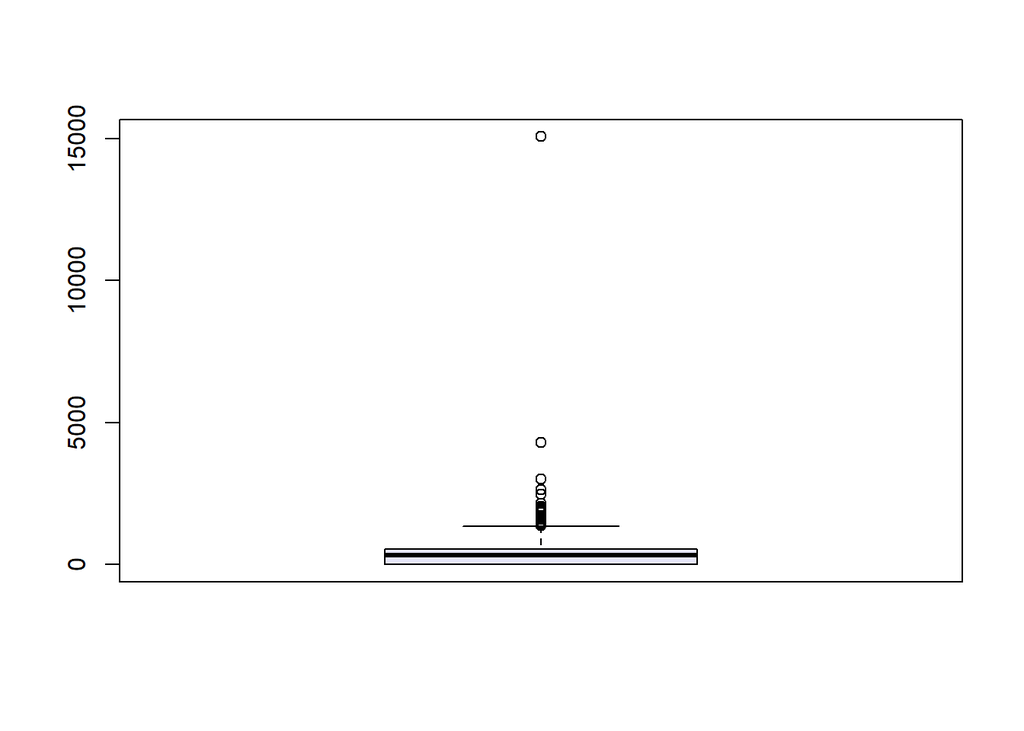

```r
boxplot(L$square_feet,col='lavender')
```

> There is a serious outlier in the square_feet variable. **15000 square feet is about 1400 square meters!** So it is clearly a wrong entry and it should be divided by 100 as it is a single bedroom as from description below.

```r
# Checking suspicious max value and replacing it
as.character(L$access[!is.na(L$square_feet) & L$square_feet == max(L$square_feet, na.rm = TRUE)])
```

```
## [1] "C'est la chambre de mon fils en campus a Nantes Vous aurez votre chambre indépendante,avec internet ethernet et wifi, il y a 2sdb et donc une sdd et un wc séparé que pour vous  vous aurez accès à la cuisine, le séjour, les parties communes et la terrasse, bien sur ainsi que la vue pour le pe…
```

```r
# Fixing this entry
L$square_feet[L$square_feet == max(L$square_feet, na.rm = TRUE)] <- 150
```

Other large apartments have been checked and seem appropriate.

## Summary infos on many columns

> Several more columns were checked with summary function, and to ease the readability of the file, the output is not shown in HTML document, but the comments are displayed right below.

```r
# Getting some info on data columns

cat("This is the summary of room type:\n")
summary(L$room_type)

cat("\nThis is the summary of experiences_offered:\n")
summary(L$experiences_offered)

cat("\nThis is the summary of bedrooms:\n")
summary(L$bedrooms)

cat("\nThis is the summary of market:\n")
summary(L$market)

cat("\nThis is the summary of country:\n")
summary(L$country)

cat("\nThis is the summary of is_location_exact:\n")
summary(L$is_location_exact)

cat("\nThis is the summary of property_type:\n")
summary(L$property_type)

cat("\nThis is the summary of accomodates:\n")
summary(L$accomodates)

cat("\nThis is the summary of review_scores_rating:\n")
summary(L$review_scores_rating)

cat("\nThis is the summary of host_is_superhost:\n")
summary(L$host_is_superhost)
```

- Some observations from summaries above:
  - Almost all the dataset concerns Apartments in Paris
  - Some variables probably won’t be useful (experiences offered, market)
  - We can check relation between reviews and price
  - There are very few superhosts, so we are currently not sure this variable will be useful.

## Neighborhood columns study

```r
cat("\nThis is the summary of host_neighborhood:\n")
head(table(L$host_neighbourhood),9)

cat("\nThis is the summary of neighborhood:\n")
head(table(L$neighbourhood),9)

cat("\nThis is the summary of neighborhood_overview:\n")
head(table(L$neighborhood_overview),3)

cat("\nThis is the summary of neighbourhood_cleansed:\n")
table(L$neighbourhood_cleansed)

cat("\nThis is the summary of has_availability:\n")
summary(L$has_availability)
```

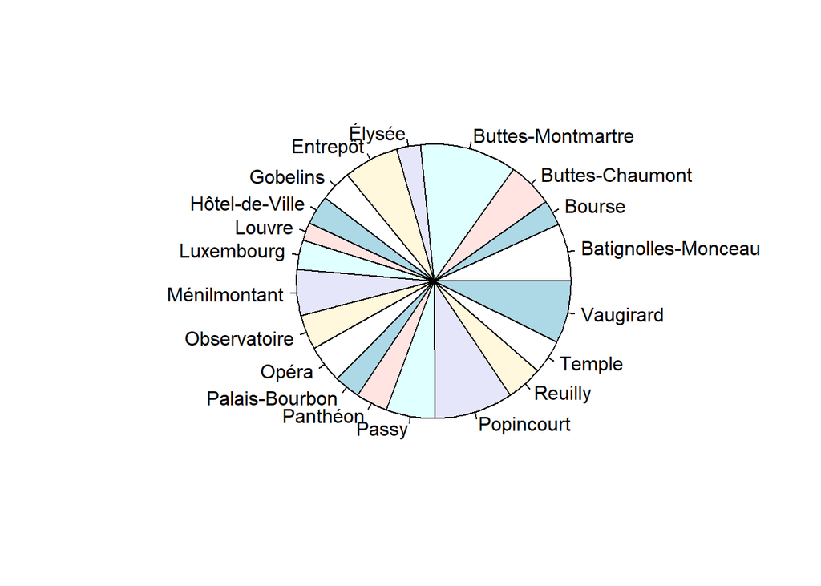

```r
pie(table(L$neighbourhood_cleansed))
```

```r
as.character(unique(L$zipcode[L$neighbourhood_cleansed == "Hôtel-de-Ville"]))
```

```
##  [1] "75004" "75001" "75003" "95000" "75011" "75009" "75005" ""      "75020"
## [10] "75017" "75002" "75006" "75012" "75018" "75019" "75010" "75013"
```

> The neighborhood_cleansed variable seems the most interesting one to study as it is well distributed.  
> But some values look suspicious, as we find too many zipcodes corresponding to each neighbouring.  
> So we will most likely not use this variable, and focus on the analysis with the zipcode variable.

# 5. Analyze relationships

## Renting price per district?

### Average price

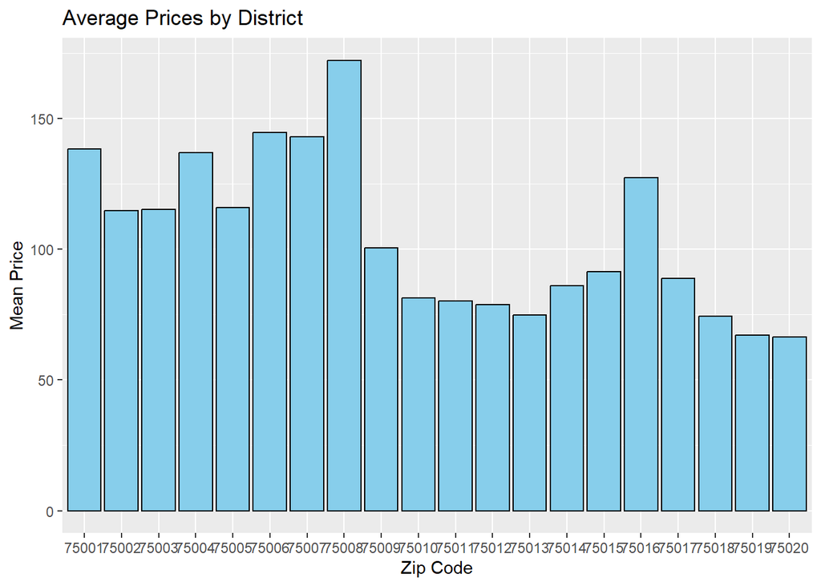

```r
# Calculate and plot mean values using dplyr
L %>%
  filter(zipcode %in% c(75001:75020)) %>%
  group_by(zipcode) %>%
  summarize(mean_price = mean(price, na.rm = TRUE)) %>%
  ggplot(aes(x = factor(zipcode), y = mean_price)) +
  theme_replace() +
  geom_bar(stat = "identity", fill = "skyblue", color = "black") +
  labs(x = "Zip Code", y = "Mean Price", title = "Average Prices by District")
```

> As far as average price is concerned, **we see a significant difference between the first 8 districts of Paris and the rest.**

### Median price

Let’s also look at median price and median absolute deviation. Here we will choose to consider arranging the prices by the median and study the median absolute deviation as they are less influenced by outliers than the mean and standard deviations.

```r
# First, check overall price statistics in Paris
L %>%
  filter(zipcode %in% c(75001:75020)) %>%
  summarise(median_price = median(price),
            mad_price = mad(price),
            iqr_price = IQR(price),
            mean_price = mean(price),
            sd_price = sd(price))
```

```
##   median_price mad_price iqr_price mean_price sd_price
## 1           75    37.065        56    96.7789 87.16053
```

```r
# Check median price and absolute deviations per district
L %>%
  filter(zipcode %in% c(75001:75020)) %>%
  group_by(zipcode) %>%
  summarise(median_price = median(price),
            mad_price = mad(price),
            iqr_price = IQR(price),
            mean_price = mean(price),
            sd_price = sd(price)) %>%
  arrange(desc(median_price))
```

```
## # A tibble: 20 × 6
##    zipcode median_price mad_price iqr_price mean_price sd_price
##    <fct>          <dbl>     <dbl>     <dbl>      <dbl>    <dbl>
##  1 75008          120        74.1     115        172.     189.
##  2 75001          111        53.4      79        138.      92.2
##  3 75006          111        57.8      91        145.     112.
##  4 75004          110        57.8      75        137.     124.
##  5 75007          100        51.9      85        143.     124.
##  6 75002           95        40.0      63        115.      72.0
##  7 75003           95        44.5      68        115.      72.7
##  8 75005           90        44.5      70.8      116.      84.8
##  9 75016           90        46.0      75        127.     138.
## 10 75009           80        37.1      60        100.      74.9
## 11 75015           75        32.6      42         91.3     88.5
## 12 75010           70        29.7      44         81.4     47.5
## 13 75011           70        29.7      40         80.1     49.9
## 14 75014           70        29.7      45         86.0     80.1
## 15 75017           70        29.7      45         88.8     70.1
## 16 75012           65        23.7      40         78.9     54.3
## 17 75018           65        23.7      35         74.4     47.0
## 18 75013           60        26.7      37         74.8     56.8
## 19 75019           58.5      24.5      32         67.2     48.6
## 20 75020           55        22.2      30         66.5     51.9
```

For the rest of analysis, notably for categorical graph faceting, we shall **choose 3 districts that represent well the distribution of prices in Paris.** Although 75008 has the highest mean and median price, it also has the highest deviations by far. So we will consider that **75001 is a better representative of the most expensive districts in Paris** (same median as 75006, but less absolute deviation and IQR). Then we will take **75015 as an average priced district** (same median as the median in whole Paris). And finally we will choose **75020 as the cheapest district as it has the lowest median**, absolute deviation and IQR in the group.

- In summary, the 3 representative districts are:
  - **1st**
  - **15th**
  - **20th**

## Number of apartments per owner?

Let’s look at the hosts who own the most apartments.

```r
# Simple way to count, arrange and limit to 20 top owners.
L %>%
  count(host_id, host_name) %>%
  arrange(desc(n)) %>%
  slice_head(n = 20)
```

```
##     host_id                 host_name   n
## 1   2288803                    Fabien 155
## 2   2667370             Parisian Home 139
## 3  12984381                   Olivier  91
## 4   3972699                    Hanane  80
## 5   3943828                  Caroline  65
## 6  21630783                    Pierre  65
## 7  39922748                     Clara  64
## 8    789620                 Charlotte  60
## 9  11593703         Rudy And Benjamin  56
## 10  3971743                     Diane  55
## 11   152242                  Delphine  54
## 12  5027164 International Home Owners  54
## 13  7612270                      Paul  53
## 14 13013633                  Benjamin  52
## 15 67879895                 Guillaume  52
## 16 23025598     My Apartment In Paris  48
## 17  1322370                   Nicolas  43
## 18  5056483                   Bettina  43
## 19  2503671                 SmartFlux  40
## 20  2107478                  Philippe  39
```

> We can further check the distribution of these hosts and the location of apartments in the Shiny app (see “Number apartments per owner” and “Map apartments per owner”).

## Relationship between prices and apartment features

### Number of beds

For the following plot, we filter on prices < 1000$ and beds <= 8 to exclude outliers, and we look at all districts.

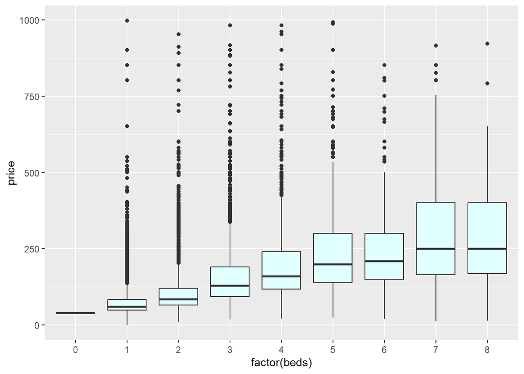

```r
L %>%
  filter(price < 1000 & beds <= 8 & zipcode %in% c(75001:75020), !is.na(beds)) %>%
  ggplot() +
  geom_boxplot(aes(x = factor(beds), y = price), fill = "lightcyan")
```

> As we expect, there is a constant increase in price according to the number of beds.  
> But **is this the same increase slope for all districts?** In particular, for the representative 1st, 15th and 20th? More study is available on Shiny app, see “Price and apartment features”.

### Reviews score influence on price

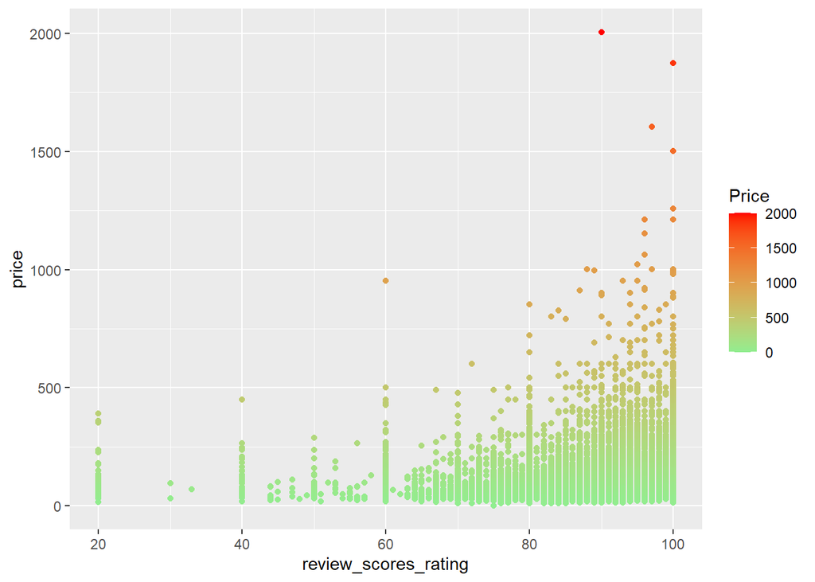

```r
L %>%
  filter(!is.na(review_scores_rating)) %>%
  ggplot() +
  geom_point(aes(x = review_scores_rating, y = price, color = price)) +
  scale_color_gradient(low = "lightgreen", high = "red") +
  labs(color = "Price")
```

> We do see some indication that high priced apartments usually have good reviews (better than 80/100).  
> But this doesn’t mean that low cost is bad! On the contrary, most ratings are good overall for all budgets.

## Visit frequency of the different districts?

### Number of visits

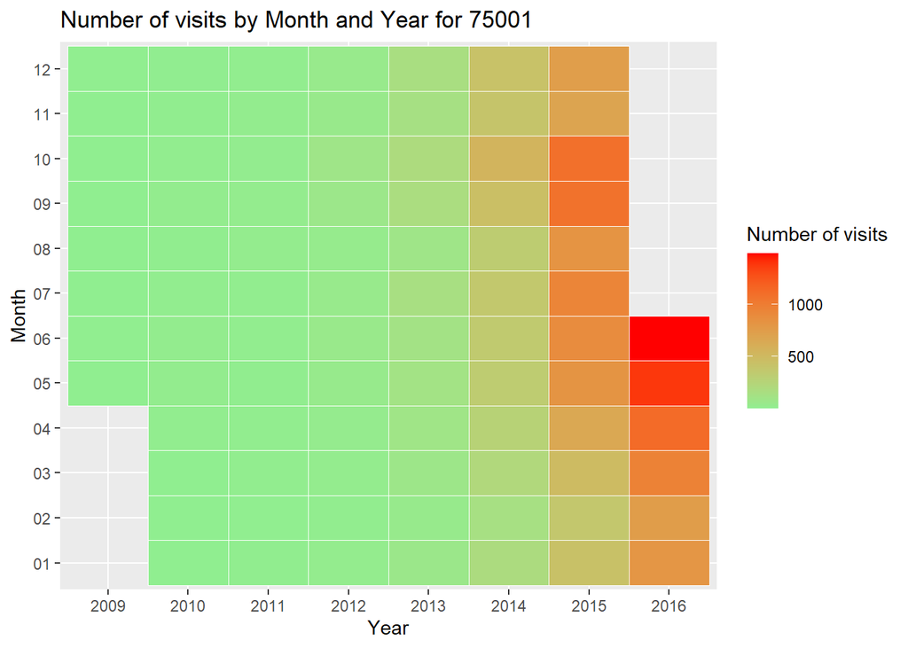

```r
# Heatmap of the visits on 1st district
L %>%
  select(id, zipcode) %>%
  filter(zipcode == 75001) %>%
  left_join(R, by = c("id" = "listing_id")) %>%
  select(date) %>%
  mutate(month = format(date, "%m"), year = format(date, "%Y")) %>%
  filter(as.Date(date) <= as.Date("2016-06-30")) %>%
  count(month, year) %>%
  ggplot(aes(x = year, y = month, fill = n)) +
  geom_tile(color = "white") +
  scale_fill_gradient(low = "lightgreen", high = "red") +
  labs(title = "Number of visits by Month and Year for 75001",
       x = "Year",
       y = "Month",
       fill = "Number of visits")
```

> It seems that the **visits were probably not well recorded until 2014** as there are too few visits prior to 2014.  
> So we will focus mostly on years 2014 to 2016 for the analysis on Shiny Apps (see “Number of visits per district” and “Frequency of visits per district”).

### Visits in relation to the number of apartments for rent

Previous plots were strictly showing absolute number of visits for a district.  
But we need to take into account **the number of apartments that are available in the district** to estimate the frequency of visit.

Let’s then look at the number of visits in relation to the number of apartments available, to have a true comparison.

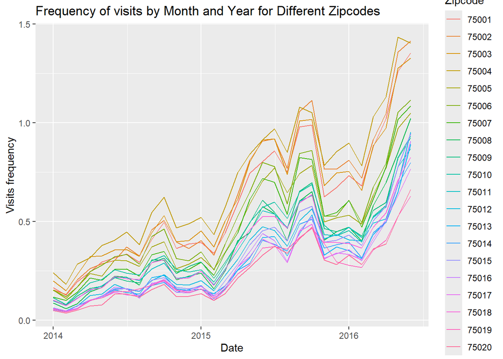

```r
R %>%
  left_join(L, by = c("listing_id" = "id")) %>%
  select(listing_id, zipcode, date) %>%
  filter(zipcode %in% c(75001:75020)) %>%
  mutate(month = format(date, "%m"), year = format(date, "%Y")) %>%
  filter(as.Date(date) >= as.Date("2014-01-01") &
         as.Date(date) <= as.Date("2016-06-30")) %>% # The data stops at June 2016.
  group_by(month, year, zipcode) %>%
  summarise(visits_per_district = n(), .groups = "drop") %>%
  left_join(L %>%
              select(id, zipcode) %>%
              group_by(zipcode) %>%
              summarise(nb_apart_per_zipcode = n_distinct(id)),
            by = "zipcode") %>%
  mutate(visits_frequency = visits_per_district / nb_apart_per_zipcode) %>%
  ggplot() +
  theme_grey() +
  geom_line(aes(x = as.Date(paste(year, month, "01", sep = "-")), y = visits_frequency, color = factor(zipcode))) +
  labs(title = "Frequency of visits by Month and Year for Different Zipcodes",
       x = "Date",
       y = "Visits frequency",
       color = "Zipcode") +
  scale_color_discrete(name = "Zipcode")
```

> It seems that there is an interesting pattern visible (the higher the district number, the lower the frequency visit). Let’s confirm this with average values:

```r
# Average visit frequency of each district
R %>%
  left_join(L, by = c("listing_id" = "id")) %>%
  select(listing_id, zipcode, date) %>%
  filter(zipcode %in% c(75001:75020)) %>%
  mutate(month = format(date, "%m"), year = format(date, "%Y")) %>%
  group_by(month, year, zipcode) %>%
  summarise(visits_per_district = n(), .groups = "drop") %>%
  left_join(L %>%
              select(id, zipcode) %>%
              group_by(zipcode) %>%
              summarise(nb_apart_per_zipcode = n_distinct(id)),
            by = "zipcode") %>%
  mutate(visits_frequency = visits_per_district / nb_apart_per_zipcode) %>%
  group_by(zipcode) %>%
  summarise(avg_freq = mean(visits_frequency)) %>%
  arrange(desc(avg_freq))
```

```
## # A tibble: 20 × 2
##    zipcode avg_freq
##    <fct>      <dbl>
##  1 75004      0.298
##  2 75002      0.286
##  3 75003      0.272
##  4 75006      0.253
##  5 75001      0.227
##  6 75007      0.200
##  7 75005      0.199
##  8 75009      0.172
##  9 75008      0.171
## 10 75010      0.170
## 11 75011      0.157
## 12 75018      0.152
## 13 75012      0.142
## 14 75015      0.138
## 15 75014      0.134
## 16 75013      0.133
## 17 75016      0.126
## 18 75017      0.120
## 19 75019      0.110
## 20 75020      0.107
```

> Interestingly enough, the districts from Paris which are the most frequently visited are very close to Paris center (4th, 2nd, 3rd, 6th and 1st districts). The frequency then decreases with the district number, **with the exception of 18th district** (more to see on this on Shiny apps).

## Relation with proximity to famous monuments?

We use a haversine formula to calculate the proximity to some famous monuments.

```r
# Function to calculate the distance between two points using the Haversine formula
haversine_distance <- function(lon1, lat1, lon2, lat2) {
  # Convert latitude and longitude from degrees to radians
  lon1 <- lon1 * pi / 180
  lat1 <- lat1 * pi / 180
  lon2 <- lon2 * pi / 180
  lat2 <- lat2 * pi / 180

  # Haversine formula
  dlon <- lon2 - lon1
  dlat <- lat2 - lat1
  a <- sin(dlat / 2)^2 + cos(lat1) * cos(lat2) * sin(dlon / 2)^2
  c <- 2 * asin(sqrt(a))
  r <- 6371000  # Radius of the Earth in meters

  return(c * r)
}
```

```r
# Apartments located less than 100m away from Sacré Coeur
L %>%
  mutate(distance_to_monument = haversine_distance(longitude, latitude, 2.343103, 48.886709)) %>%
  filter(distance_to_monument < 100) %>%
  leaflet() %>%
      addTiles() %>%
      addPopups(lng = ~longitude,
                 lat = ~latitude,
                 popup = ~paste("$", price))
```

[interactive chart not shown]

> See **Shiny app “Proximity with monuments”.** There is a definite impact on price when apartments are located near a famous monument like Eiffel Tower. However we do find some affordable apartments still in these neighborhoods. Overall, the neighborhood of Montmartre and Sacré Coeur seems to be the most attractive thanks to the reasonable prices and the quantity of apartments available.

# Conclusion

In conclusion, the dataset allowed us to capture some interesting insights.  
The price of apartments, characteristics and visit frequency are highly correlated to their location (district), particularly to their distance from the center of Paris.  
But there are also exceptions to this general rule, and it appears that one could definitely recommend considering 18th district, to allow for a nice affordable stay in Paris while visiting a very pleasant side of Paris.

[figure not shown]